# TiDEomics Application: Macrophage response to six immune stimuli

Tianen He

University of Oxford

tianen.he@ndm.ox.ac.uk

11 June 2026

#### Package

TiDEomics 0.99.1

# 1 Introduction

[**TiDEomics**](https://github.com/hte123/TiDEomics) is an R package designed to streamline analysis of time-course omics data (e.g. proteomics, transcriptomics), compatible with both single group analysis and multiple group comparison, and accommodating data with missing values.

Here we present a full analysis workflow using TiDEomics on a time-course transcriptomics dataset of murine macrophage exposed to six immune stimuli, with samples collected at 0, 2, 4, 6, 8, and 24 hours post-stimulation. The data set is from GSE263759 published in Traxler et al. (2025).

# 2 Package dependencies

```r
if (!require("remotes", quietly = TRUE)) install.packages("remotes")

remotes::install_github("hte123/TiDEomics")
```

```r
library(TiDEomics)
library(magrittr)
library(SummarizedExperiment)
library(org.Mm.eg.db)
library(GEOquery)
library(stringr)
library(dplyr)
```

```r
library(ggplot2)
```

# 3 Input data

GSE263759 dataset is downloaded and processed:

- Ensembl IDs were mapped to symbols, genes with zero counts in all samples were excluded.
- Use time 0 untreated samples for other groups’ time 0.

A subset of the data is stored in `data/tutorial_sample_info.rda` and `data/tutorial_data.rda` for use in the Tutorial, as recorded in `data-raw/tutorial_input.R`.

```r
# download sample information from GEO
geo_data <- getGEO("GSE263759", GSEMatrix = TRUE)
```

```
#> Found 1 file(s)
#> GSE263759_series_matrix.txt.gz
```

```r
geo_sample_info <- pData(geo_data[[1]]) %>%
  dplyr::select(
    "title", "stimulus:ch1", "time point:ch1",
    "bio-replicate:ch1", "batch:ch1"
  ) %>%
  dplyr::rename(
    "Group" = "stimulus:ch1",
    "Time" = "time point:ch1",
    "Replicate" = "bio-replicate:ch1",
    "Batch" = "batch:ch1",
    "Sample" = "title"
  ) %>%
  mutate(
    Time = Time %>% str_replace("h", "") %>% as.numeric(),
    Replicate = Replicate %>% str_replace("R", "") %>% as.numeric(),
    Batch = Batch %>% as.numeric()
  )
row.names(geo_sample_info) <- NULL

geo_sample_info %>%
  dplyr::group_by(Group) %>%
  dplyr::summarise(n = n())
```

| Group | n |
| --- | --- |
| Candida | 10 |
| IFNbeta | 10 |
| IFNgamma | 10 |
| LCMV | 10 |
| LPS | 9 |
| Listeria | 10 |
| untreated | 5 |

```r
# download expression matrix from GEO
getGEOSuppFiles("GSE263759", baseDir = "..//..//data-raw", makeDirectory = FALSE)
```

```
#> Using locally cached version of supplementary file(s) GSE263759 found here:
#> ..//..//data-raw/GSE263759_RNA_raw_counts.csv.gz
```

[output not shown]

```r
geo_data_tb_gz <- gzfile("..//..//data-raw//GSE263759_RNA_raw_counts.csv.gz", 'rt')
geo_data_tb <- read.csv(geo_data_tb_gz) %>%
  dplyr::rename("Feature" = "gene")

# map ensembl IDs to gene symbols
geo_data_tb_symbol <- geo_data_tb$Feature %>%
  clusterProfiler::bitr(fromType = "ENSEMBL", toType = "SYMBOL", OrgDb = org.Mm.eg.db) %>%
  merge(geo_data_tb, by.x = "ENSEMBL", by.y = "Feature") %>%
  distinct(SYMBOL, .keep_all = TRUE) %>%
  dplyr::select(-ENSEMBL) %>%
  dplyr::rename("Feature" = "SYMBOL")
```

```
#>
#> Warning in clusterProfiler::bitr(., fromType = "ENSEMBL", toType = "SYMBOL", :
#> 41.32% of input gene IDs are fail to map...
```

```r
# remove genes with all zero counts
gene_keep <- geo_data_tb_symbol[, -1] %>%
  apply(1, function(x) sum(x)) %>%
  `!=`(0) %>%
  which()
geo_data_tb_filtered <- geo_data_tb_symbol[gene_keep, ]

# apply time 0 of untreated to all groups
# duplicate the time 0 untreated samples to all other samples' time 0
geo_sample_info_new <- geo_sample_info
geo_data_tb_new <- geo_data_tb_filtered

for (i in unique(geo_sample_info$Group)) {
  if (i != "untreated") {
    group_t0 <- geo_data_tb_filtered %>%
      dplyr::select(starts_with("RNA_untreated_0h"))
    group_t0_sample <- geo_sample_info %>%
      filter(Group == "untreated" & Time == 0)

    colnames(group_t0) <- colnames(group_t0) %>%
      str_replace("untreated", i)
    geo_data_tb_new <- cbind(geo_data_tb_new, group_t0)

    group_t0_sample <- group_t0_sample %>%
      mutate(
        Sample = Sample %>%
          str_replace("RNA_untreated", paste0("RNA_", i)),
        Group = i
      )
    geo_sample_info_new <- rbind(geo_sample_info_new, group_t0_sample)
  }
}
```

```r
data_obj <- create_input(
    data = geo_data_tb_new,
    sample_ann = geo_sample_info_new)
```

```
#> No Subject column specified. Samples treated as independent. For repeated-measures designs, set subject_col to the column identifying biological subjects.
#> Converting 'Group' column to factor. Default order is alphabetical.
#> Converting 'Replicate' column to factor. Default order is numerical.
#> Converting 'Batch' column to factor. Default order is numerical.
```

```r
# Log-transform the data when not already done
assays(data_obj)[[1]] <- log2(assays(data_obj)[[1]] + 1) # + 1 to avoid log(0)

data_obj
```

```
#> class: SummarizedExperiment
#> dim: 20150 76
#> metadata(0):
#> assays(1): ''
#> rownames(20150): Gnai3 Cdc45 ... Gm17315 Ube2srt
#> rowData names(0):
#> colnames(76): RNA_Candida_0h_R1_1 RNA_Candida_0h_R2_1 ...
#>   RNA_untreated_24h_R1_2 RNA_untreated_24h_R2_2
#> colData names(5): Sample Group Time Replicate Batch
```

The log2 (raw count + 1) is used as the input, stored in the first assay slot of `data_obj`.

```r
assays(data_obj)[[1]] %>% head() # first few rows of the data matrix
```

|  | RNA_Candida_0h_R1_1 | RNA_Candida_0h_R2_1 | RNA_Candida_2h_R1_1 | RNA_Candida_2h_R2_1 | RNA_Candida_4h_R1_1 | RNA_Candida_4h_R2_1 | RNA_Candida_6h_R1_1 | RNA_Candida_6h_R2_1 | RNA_Candida_8h_R1_2 | RNA_Candida_8h_R2_2 | RNA_Candida_24h_R1_2 | RNA_Candida_24h_R2_2 | RNA_IFNbeta_0h_R1_1 | RNA_IFNbeta_0h_R2_1 | RNA_IFNbeta_2h_R1_1 | RNA_IFNbeta_2h_R2_1 | RNA_IFNbeta_4h_R1_1 | RNA_IFNbeta_4h_R2_1 | RNA_IFNbeta_6h_R1_1 | RNA_IFNbeta_6h_R2_1 | RNA_IFNbeta_8h_R1_2 | RNA_IFNbeta_8h_R2_2 | RNA_IFNbeta_24h_R1_2 | RNA_IFNbeta_24h_R2_2 | RNA_IFNgamma_0h_R1_1 | RNA_IFNgamma_0h_R2_1 | RNA_IFNgamma_2h_R1_1 | RNA_IFNgamma_2h_R2_1 | RNA_IFNgamma_4h_R1_1 | … |
| --- | --- | --- | --- | --- | --- | --- | --- | --- | --- | --- | --- | --- | --- | --- | --- | --- | --- | --- | --- | --- | --- | --- | --- | --- | --- | --- | --- | --- | --- | --- |
| Gnai3 | 6.882643 | 6.832890 | 7.159871 | 6.820179 | 7.312883 | 7.257388 | 7.459432 | 7.149747 | 7.636625 | 7.857981 | 7.055282 | 7.507795 | 6.882643 | 6.832890 | 7.044394 | 5.584963 | 7.044394 | 6.285402 | 7.169925 | 6.459432 | 6.906891 | 7.857981 | 6.754888 | 7.087463 | 6.882643 | 6.832890 | 7.139551 | 6.643856 | 6.629357 | … |
| Cdc45 | 6.108524 | 6.129283 | 6.000000 | 5.614710 | 5.857981 | 5.209453 | 5.882643 | 4.754888 | 5.643856 | 6.209453 | 6.189825 | 5.832890 | 6.108524 | 6.129283 | 5.954196 | 4.954196 | 4.954196 | 4.906891 | 4.584963 | 4.247928 | 4.807355 | 4.584963 | 2.584963 | 3.906891 | 6.108524 | 6.129283 | 6.022368 | 5.727920 | 5.169925 | … |
| H19 | 0.000000 | 0.000000 | 0.000000 | 0.000000 | 0.000000 | 0.000000 | 0.000000 | 0.000000 | 0.000000 | 0.000000 | 0.000000 | 1.000000 | 0.000000 | 0.000000 | 0.000000 | 0.000000 | 0.000000 | 1.000000 | 0.000000 | 1.000000 | 0.000000 | 0.000000 | 0.000000 | 0.000000 | 0.000000 | 0.000000 | 0.000000 | 0.000000 | 0.000000 | … |
| Scml2 | 1.584963 | 2.321928 | 1.000000 | 2.321928 | 1.584963 | 1.000000 | 2.000000 | 2.584963 | 0.000000 | 0.000000 | 2.000000 | 2.584963 | 1.584963 | 2.321928 | 2.321928 | 2.807355 | 2.000000 | 1.000000 | 1.584963 | 1.000000 | 2.000000 | 0.000000 | 0.000000 | 0.000000 | 1.584963 | 2.321928 | 1.584963 | 1.584963 | 0.000000 | … |
| Narf | 5.426265 | 5.554589 | 5.426265 | 4.169925 | 5.977280 | 6.491853 | 6.066089 | 5.930737 | 5.807355 | 5.643856 | 6.442943 | 5.754888 | 5.426265 | 5.554589 | 4.169925 | 4.000000 | 3.000000 | 2.584963 | 4.857981 | 5.209453 | 6.539159 | 6.339850 | 7.303781 | 6.599913 | 5.426265 | 5.554589 | 5.977280 | 5.087463 | 5.727920 | … |
| Cav2 | 8.511753 | 8.531381 | 7.876517 | 8.257388 | 7.149747 | 7.651052 | 7.622052 | 8.022368 | 7.554589 | 7.483816 | 7.971544 | 7.948367 | 8.511753 | 8.531381 | 7.614710 | 7.977280 | 6.754888 | 7.044394 | 6.807355 | 6.108524 | 5.700440 | 5.392317 | 8.214319 | 7.820179 | 8.511753 | 8.531381 | 7.734710 | 7.826548 | 7.228819 | … |

```r
colData(data_obj) # sample annotation
```

```
#> DataFrame with 76 rows and 5 columns
#>                                        Sample     Group      Time Replicate
#>                                   <character>  <factor> <numeric>  <factor>
#> RNA_Candida_0h_R1_1       RNA_Candida_0h_R1_1   Candida         0         1
#> RNA_Candida_0h_R2_1       RNA_Candida_0h_R2_1   Candida         0         2
#> RNA_Candida_2h_R1_1       RNA_Candida_2h_R1_1   Candida         2         1
#> RNA_Candida_2h_R2_1       RNA_Candida_2h_R2_1   Candida         2         2
#> RNA_Candida_4h_R1_1       RNA_Candida_4h_R1_1   Candida         4         1
#> ...                                       ...       ...       ...       ...
#> RNA_untreated_0h_R1_1   RNA_untreated_0h_R1_1 untreated         0         1
#> RNA_untreated_0h_R2_1   RNA_untreated_0h_R2_1 untreated         0         2
#> RNA_untreated_8h_R2_2   RNA_untreated_8h_R2_2 untreated         8         2
#> RNA_untreated_24h_R1_2 RNA_untreated_24h_R1_2 untreated        24         1
#> RNA_untreated_24h_R2_2 RNA_untreated_24h_R2_2 untreated        24         2
#>                           Batch
#>                        <factor>
#> RNA_Candida_0h_R1_1           1
#> RNA_Candida_0h_R2_1           1
#> RNA_Candida_2h_R1_1           1
#> RNA_Candida_2h_R2_1           1
#> RNA_Candida_4h_R1_1           1
#> ...                         ...
#> RNA_untreated_0h_R1_1         1
#> RNA_untreated_0h_R2_1         1
#> RNA_untreated_8h_R2_2         2
#> RNA_untreated_24h_R1_2        2
#> RNA_untreated_24h_R2_2        2
```

## 3.1 Set custom color palette

```r
custom_palette <- c(
    "untreated" = "#7570b3",
    "IFNbeta" = "#e6ab02",
    "IFNgamma" = "#a6761d",
    "LPS" = "#66a61e",
    "Candida" = "#e7298a",
    "LCMV" = "#d95f02",
    "Listeria" = "#1b9e77"
)
set_custom_palette(custom_palette)
```

```
#> Custom palette has been set successfully for groups untreated, IFNbeta, IFNgamma, LPS, Candida, LCMV, Listeria.
```

# 4 Quality control

Abundance distribution

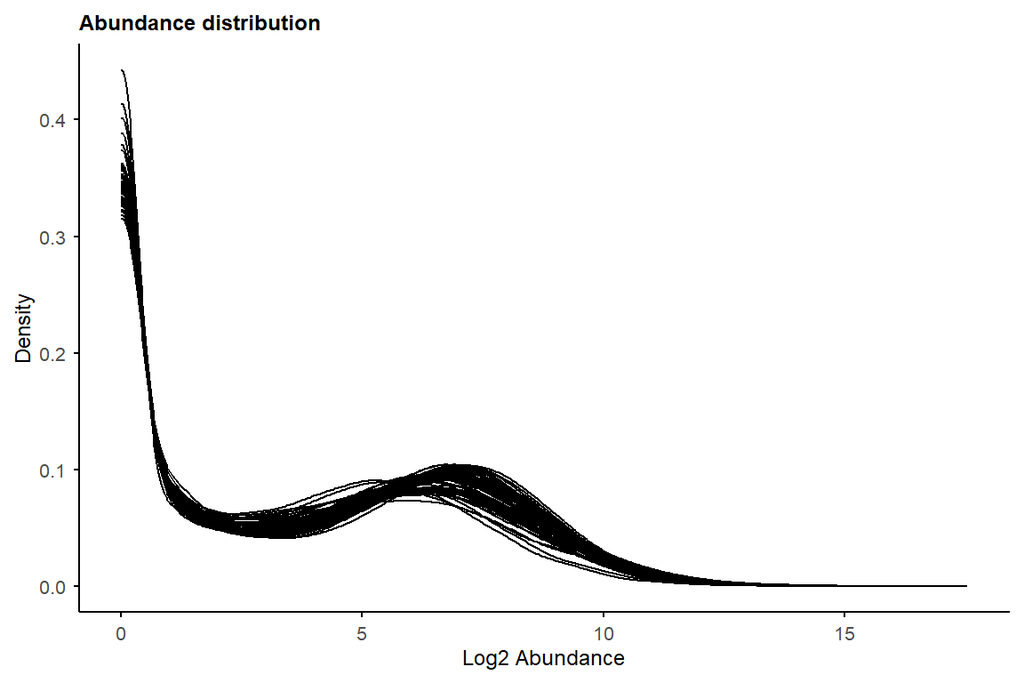

```r
plot_distribution(data_obj)
```

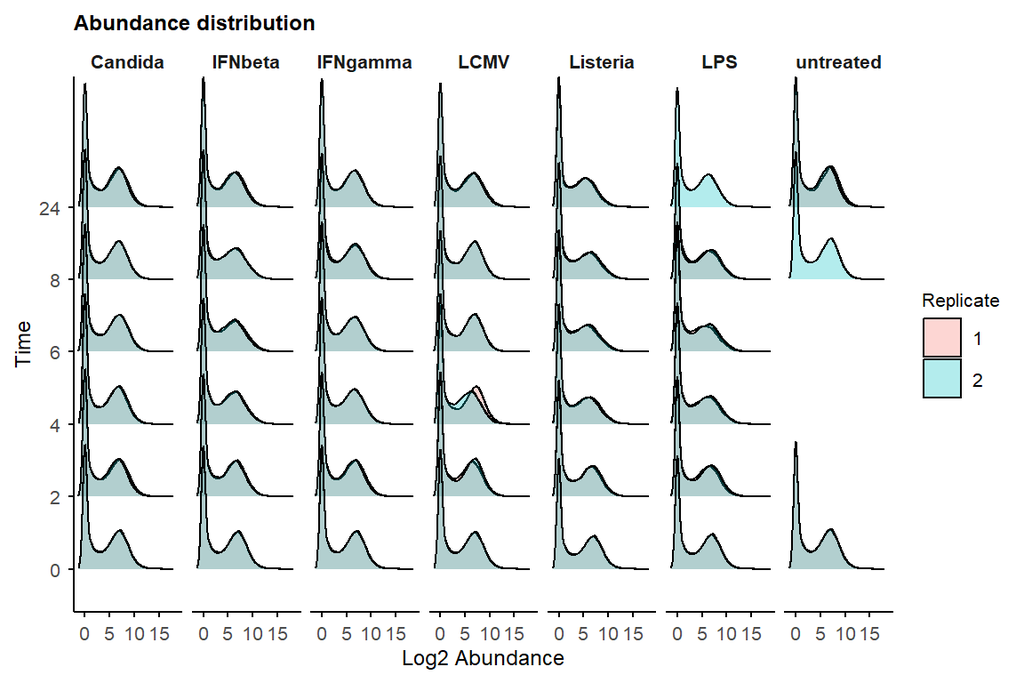

```r
plot_distribution(data_obj, facet_by = "Group")
```

# 5 Data processing

Normalise to time point 0

```r
data_obj <- normalise_to_start(data_obj)
```

```
#> Normalising to group baseline at each feature's first non-NA time point.
```

Split object into one per group

```r
data_obj_list <- split_groups(data_obj)
```

Merge replicates by mean

```r
data_obj_merged_list <- merge_replicates(data_obj_list)
```

Merge groups into one object with merged replicates

```r
data_obj_merged <- merge_groups(data_obj_merged_list)
data_obj_merged
```

```
#> class: SummarizedExperiment
#> dim: 20150 39
#> metadata(0):
#> assays(2): '' ''
#> rownames(20150): Gnai3 Cdc45 ... Gm17315 Ube2srt
#> rowData names(0):
#> colnames(39): Candida_0 Candida_2 ... untreated_8 untreated_24
#> colData names(5): Sample Group Time Replicate Batch
```

## 5.1 Calculate mean and SD for plotting

```r
table_mean_sd_list <- calc_mean_sd(data_obj)
table_mean_sd_orig <- table_mean_sd_list$orig
table_mean_sd_norm <- table_mean_sd_list$norm0
```

## 5.2 Visualise example genes expression

`plot_trend()` accepts either a `SummarizedExperiment` object directly (with `assay` parameter) or a pre-computed table from `calc_mean_sd()`.

```
#> Group not specified. Plotting all groups: Candida, IFNbeta, IFNgamma, LCMV, Listeria, LPS, untreated
#> Warning: Removed 12 rows containing missing values or values outside the scale range
#> (`geom_point()`).
```

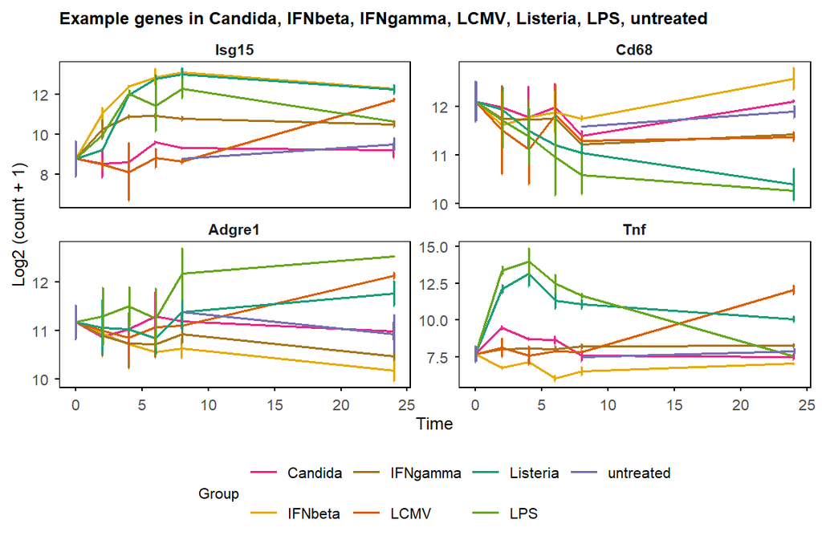

```r
# Using pre-computed table
plot_trend(table_mean_sd_orig,
    features = c("Isg15", "Cd68", "Adgre1", "Tnf"),
    title = "Example genes", ylab = "Log2 (count + 1)"
)
```

```
#> Group not specified. Plotting all groups: Candida, IFNbeta, IFNgamma, LCMV, Listeria, LPS, untreated
#> Warning: Removed 12 rows containing missing values or values outside the scale range
#> (`geom_point()`).
```

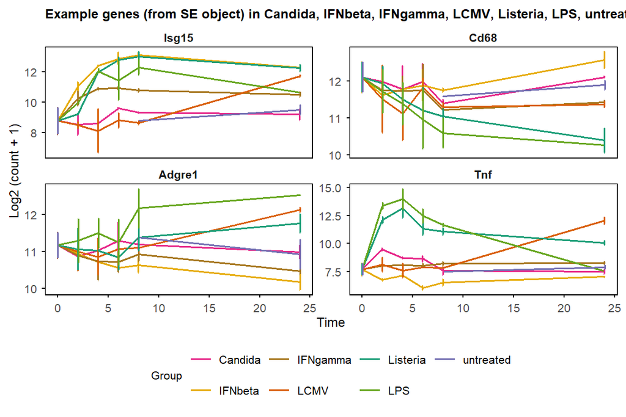

```r
# Using SummarizedExperiment directly
plot_trend(data_obj, assay = 1,
    features = c("Isg15", "Cd68", "Adgre1", "Tnf"),
    title = "Example genes (from SE object)", ylab = "Log2 (count + 1)"
)
```

# 6 Sample relationships

## 6.1 Correlation between samples

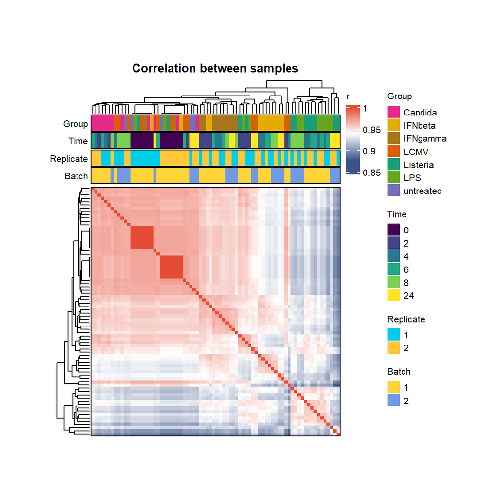

```r
plot_cor_matrix(data_obj,
    method = "spearman",
    label_rep = TRUE, label_batch = TRUE,
    cellwidth = 1.5, cellheight = 1.5
)
```

## 6.2 UMAP

using original data not normalised to time 0

### 6.2.1 Original data with replicates

#### 6.2.1.1 All groups

```
#> Using n_neighbors = 15
```

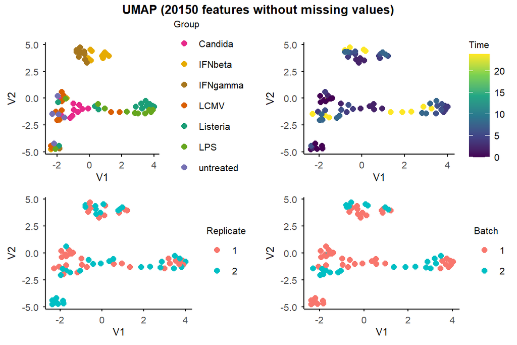

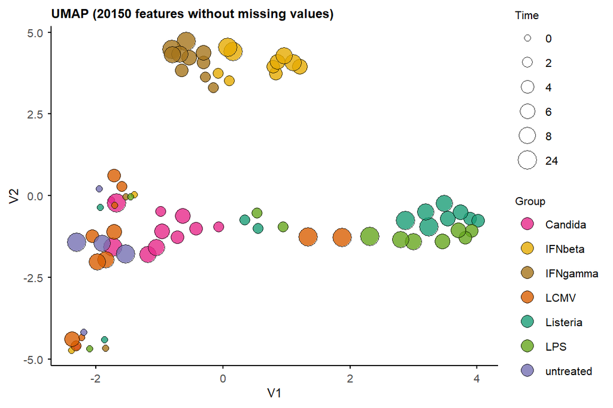

```r
umap_layout <- plot_umap(data_obj, seed = 123)
```

#### 6.2.1.2 Per group

```
#> Using n_neighbors = 5
#> Using n_neighbors = 5
#> Using n_neighbors = 5
#> Using n_neighbors = 5
#> Using n_neighbors = 5
#> Using n_neighbors = 5
#> Using n_neighbors = 4
```

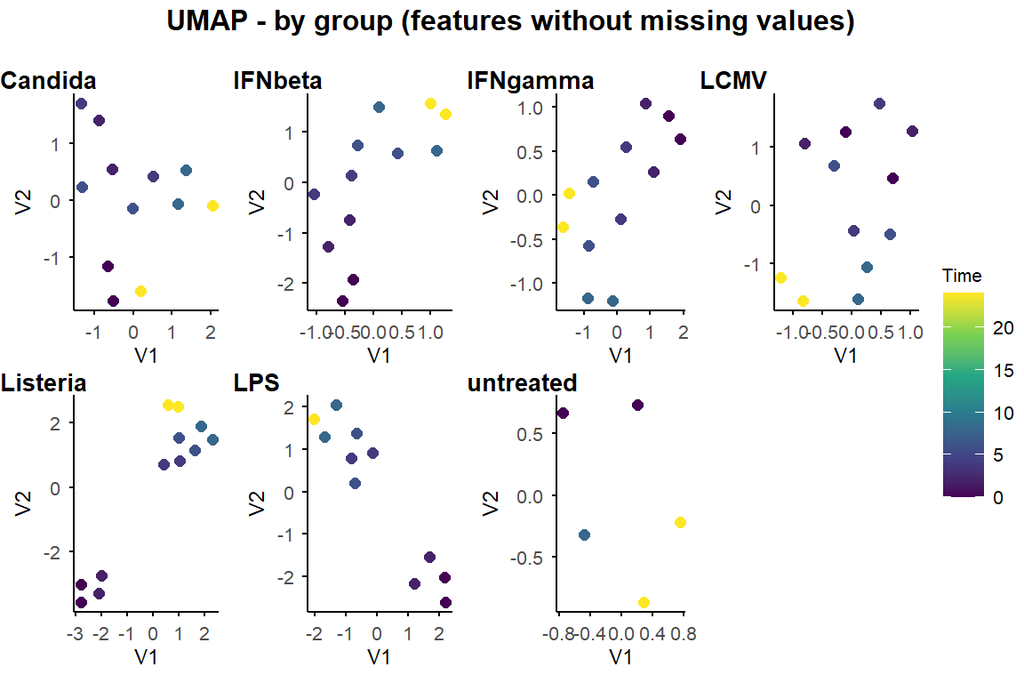

```r
plot_umap_by_group(data_obj, nrow = 2, seed = 123)
```

```r
# same as plot_umap_by_group(data_obj_list)
```

### 6.2.2 Replicates merged by mean

#### 6.2.2.1 All groups

```
#> Using n_neighbors = 7
```

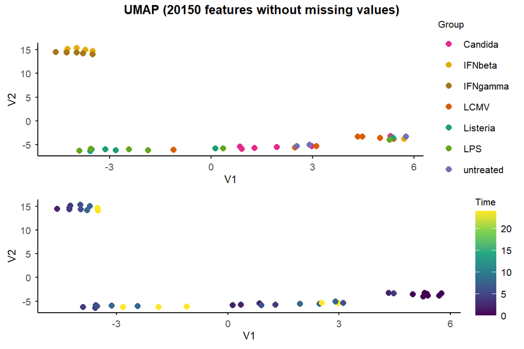

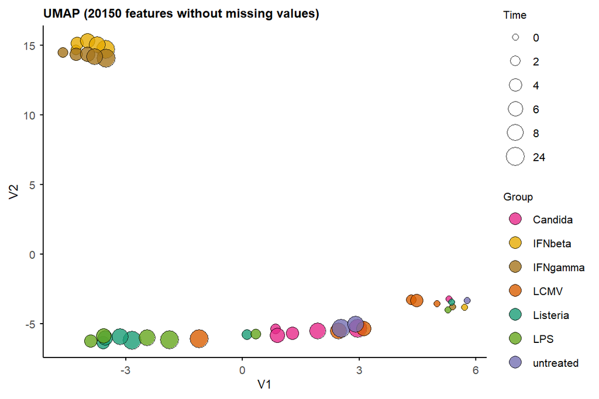

```r
umap_layout <- plot_umap(data_obj_merged, seed = 123)
```

#### 6.2.2.2 Per group

```
#> Using n_neighbors = 5
#> Using n_neighbors = 5
#> Using n_neighbors = 5
#> Using n_neighbors = 5
#> Using n_neighbors = 5
#> Using n_neighbors = 5
#> Using n_neighbors = 2
#> Warning: failed creating initial embedding; using random embedding instead
```

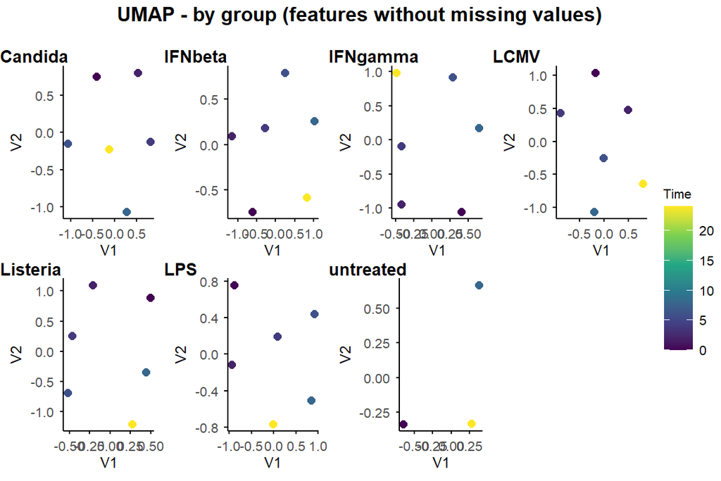

```r
plot_umap_by_group(data_obj_merged, nrow = 2)
```

```r
# same as plot_umap_by_group(data_obj_merged_list)
```

## 6.3 PCA

using original data not normalised to time 0

### 6.3.1 Original data with replicates

#### 6.3.1.1 All groups

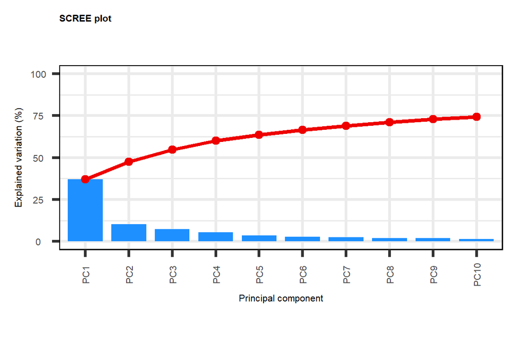

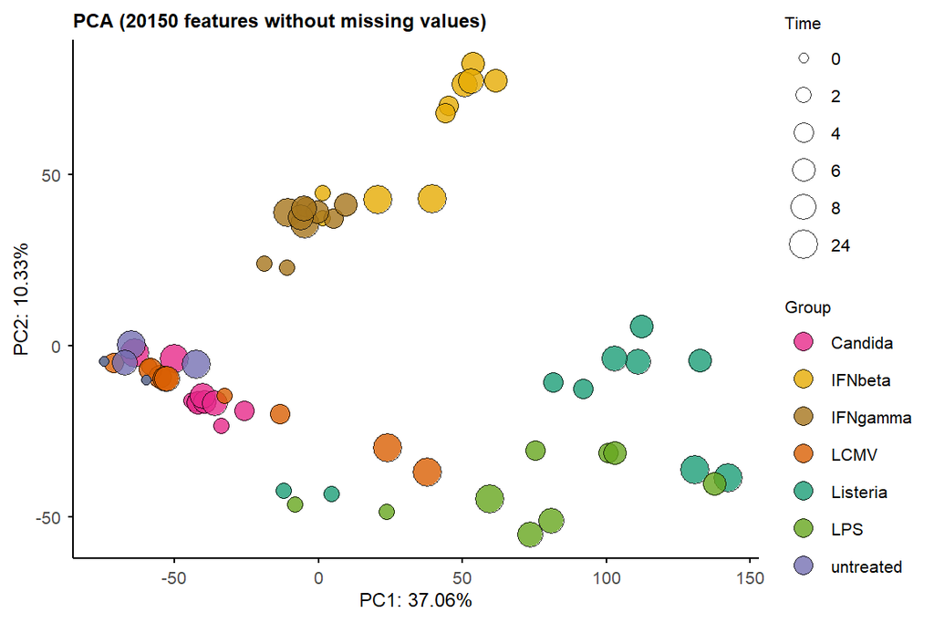

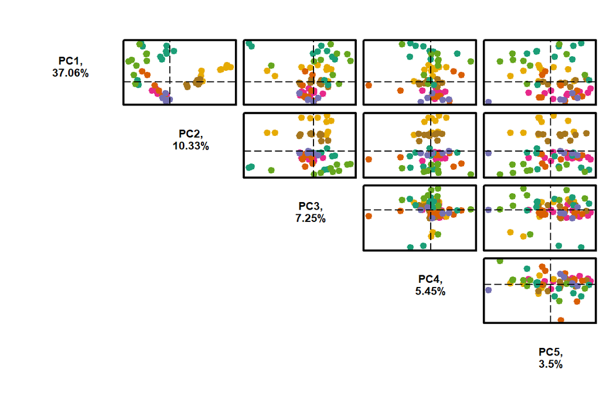

```r
PC <- plot_pca(data_obj,
    plot = TRUE,
    plot_screeplot = TRUE,
    plot_loadings = FALSE,
    plot_morepc = TRUE,
    circle = FALSE,
    morepc = 1:5
)
```

```r
plot_pca_3D(PC, pcs = 1:3)
```

[interactive chart not shown]

Note: the 3D plot may not display properly in some html, but should work in an interactive R session.

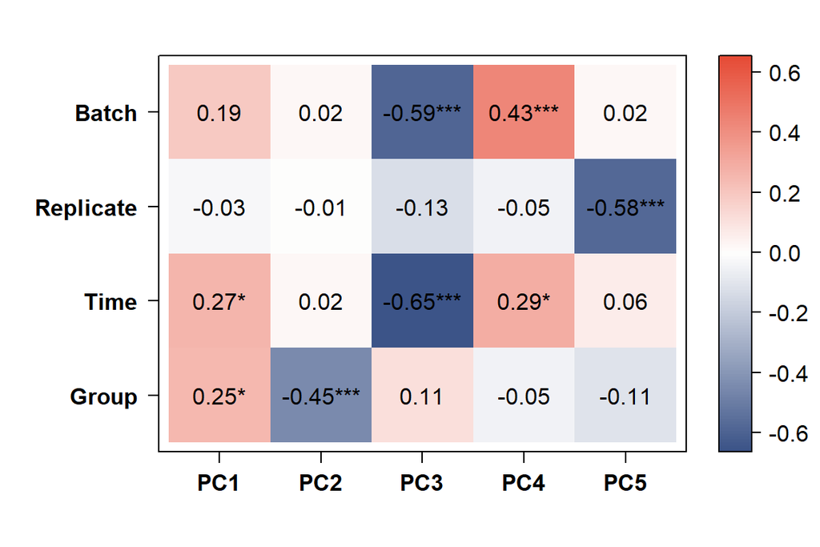

```r
PCAtools::eigencorplot(PC,
    metavars = c("Group", "Time", "Replicate", "Batch"),
    components = paste0("PC", 1:5),
    col = colorRampPalette(c("#3C5488FF", "white", "#E64B35FF"))(100),
    colCorval = "black"
)
```

#### 6.3.1.2 Per group

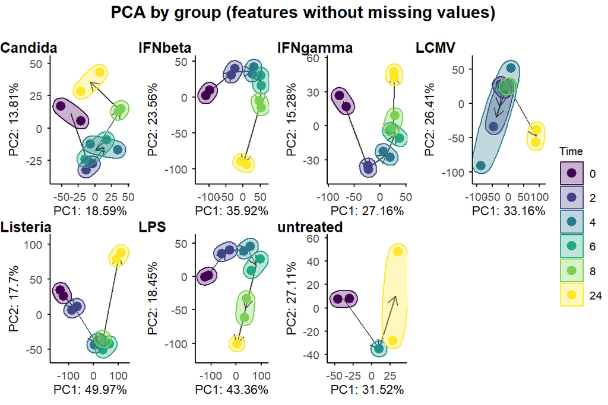

```r
plot_pca_by_group(data_obj, circle = TRUE, arrow = TRUE, nrow = 2)
```

```r
# same as plot_pca_by_group(data_obj_list, circle = TRUE, arrow = TRUE)
```

### 6.3.2 Replicates merged by mean

#### 6.3.2.1 All groups

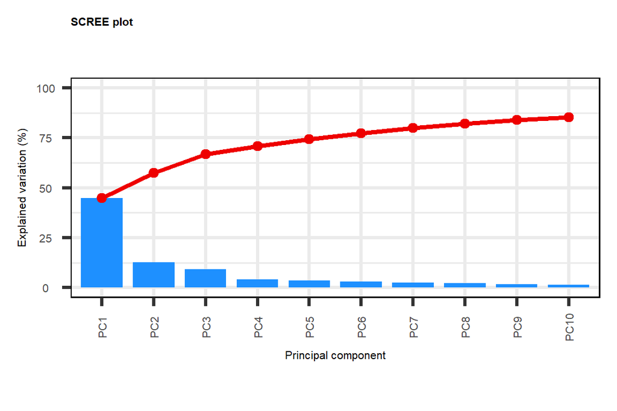

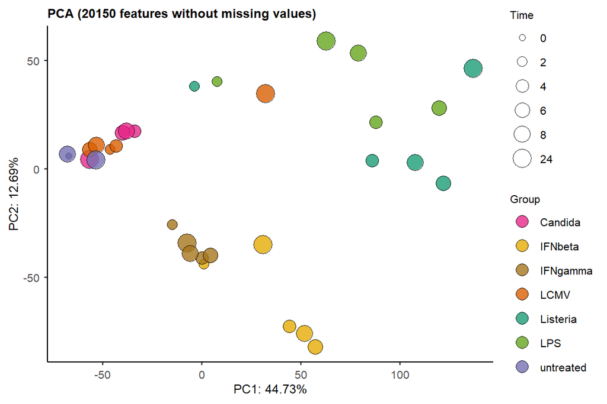

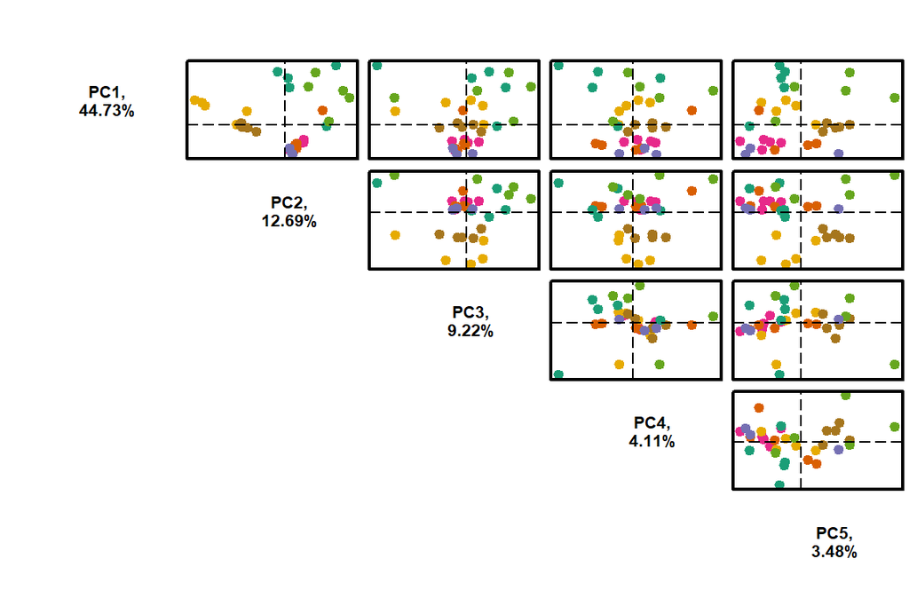

```r
PC_merged <- plot_pca(data_obj_merged,
    plot = TRUE,
    plot_screeplot = TRUE,
    plot_loadings = FALSE,
    plot_morepc = TRUE,
    circle = FALSE,
    morepc = 1:5
)
```

```r
plot_pca_3D(PC_merged, pcs = 1:3)
```

[interactive chart not shown]

Note: the 3D plot may not display properly in some html, but should work in an interactive R session.

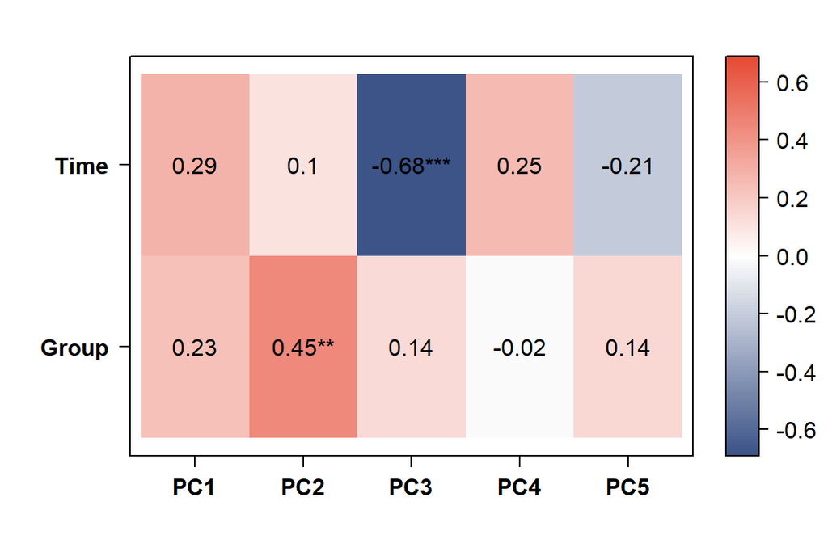

```r
PCAtools::eigencorplot(PC_merged,
    metavars = c("Group", "Time"),
    components = paste0("PC", 1:5),
    col = colorRampPalette(c("#3C5488FF", "white", "#E64B35FF"))(100),
    colCorval = "black"
)
```

#### 6.3.2.2 Per group

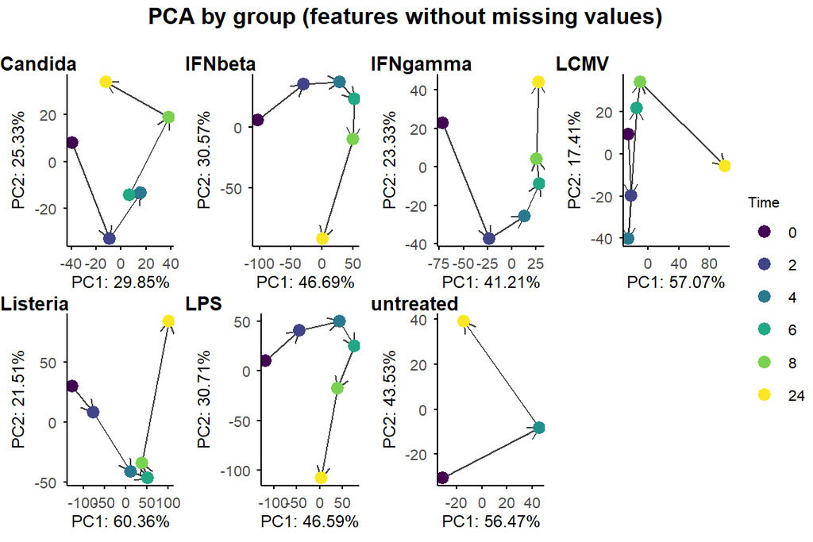

```r
plot_pca_by_group(data_obj_merged_list, nrow = 2, circle = FALSE)
```

# 7 Top correlated genes with PCs

top correlated (loading) genes with each principal components (PC)

## 7.1 Original data with replicates

```
#> Group not specified. Plotting all groups: Candida, IFNbeta, IFNgamma, LCMV, Listeria, LPS, untreated
#> Warning: Removed 90 rows containing missing values or values outside the scale range
#> (`geom_point()`).
```

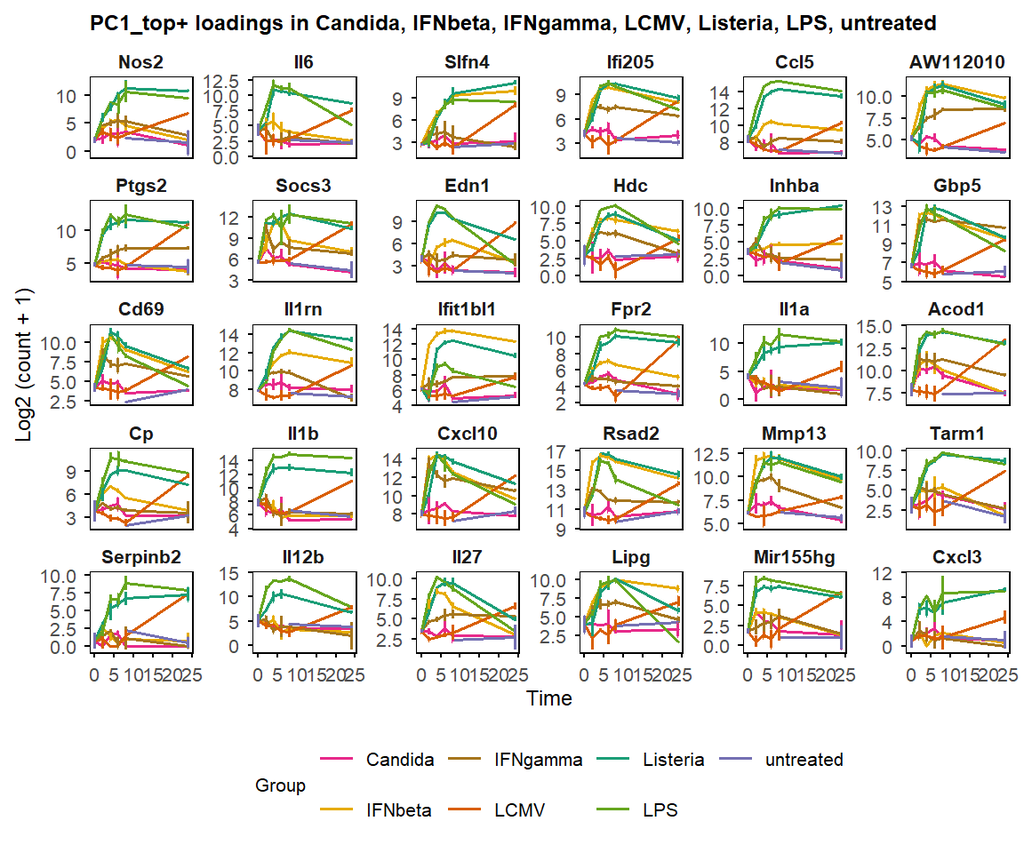

```
#> Group not specified. Plotting all groups: Candida, IFNbeta, IFNgamma, LCMV, Listeria, LPS, untreated
#> Warning: Removed 90 rows containing missing values or values outside the scale range
#> (`geom_point()`).
```

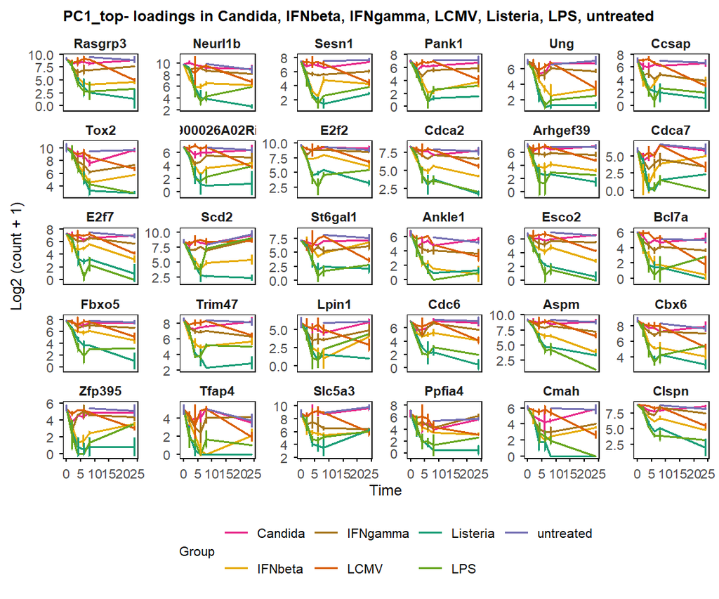

```
#> Group not specified. Plotting all groups: Candida, IFNbeta, IFNgamma, LCMV, Listeria, LPS, untreated
#> Warning: Removed 90 rows containing missing values or values outside the scale range
#> (`geom_point()`).
```

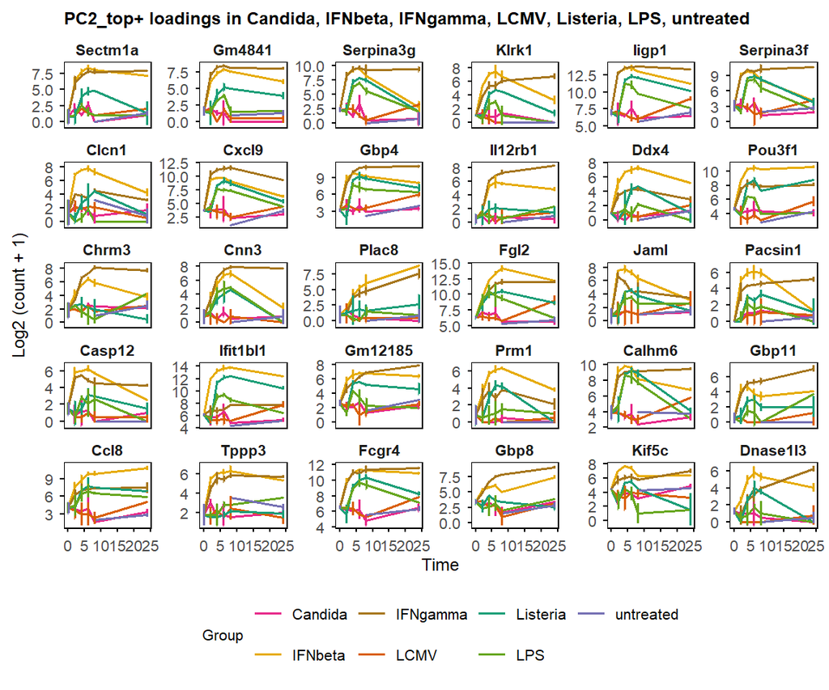

```
#> Group not specified. Plotting all groups: Candida, IFNbeta, IFNgamma, LCMV, Listeria, LPS, untreated
#> Warning: Removed 90 rows containing missing values or values outside the scale range
#> (`geom_point()`).
```

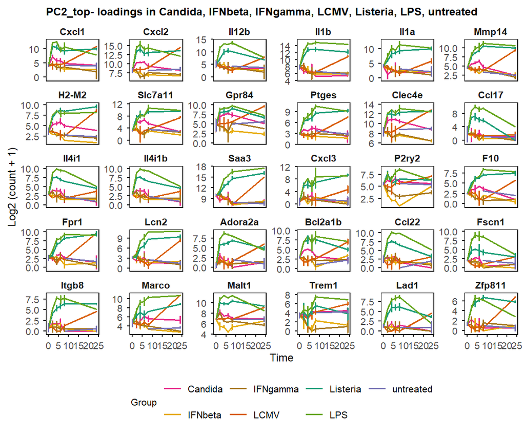

```
#> Group not specified. Plotting all groups: Candida, IFNbeta, IFNgamma, LCMV, Listeria, LPS, untreated
#> Warning: Removed 90 rows containing missing values or values outside the scale range
#> (`geom_point()`).
```

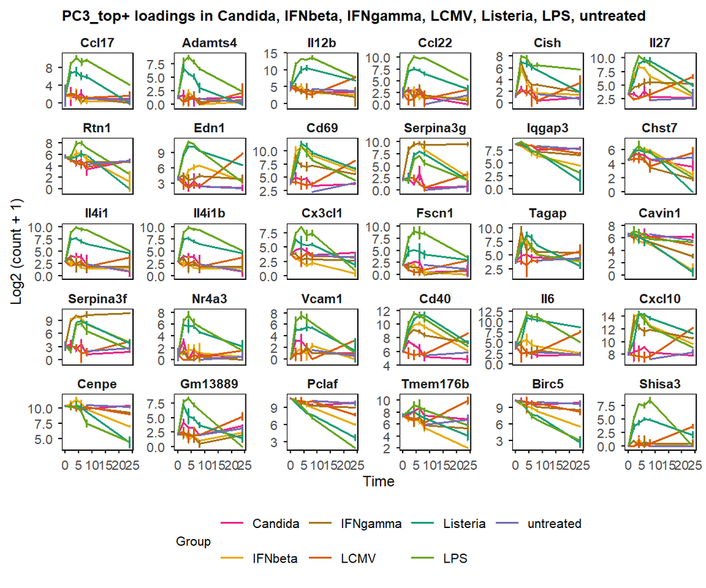

```
#> Group not specified. Plotting all groups: Candida, IFNbeta, IFNgamma, LCMV, Listeria, LPS, untreated
#> Warning: Removed 90 rows containing missing values or values outside the scale range
#> (`geom_point()`).
```

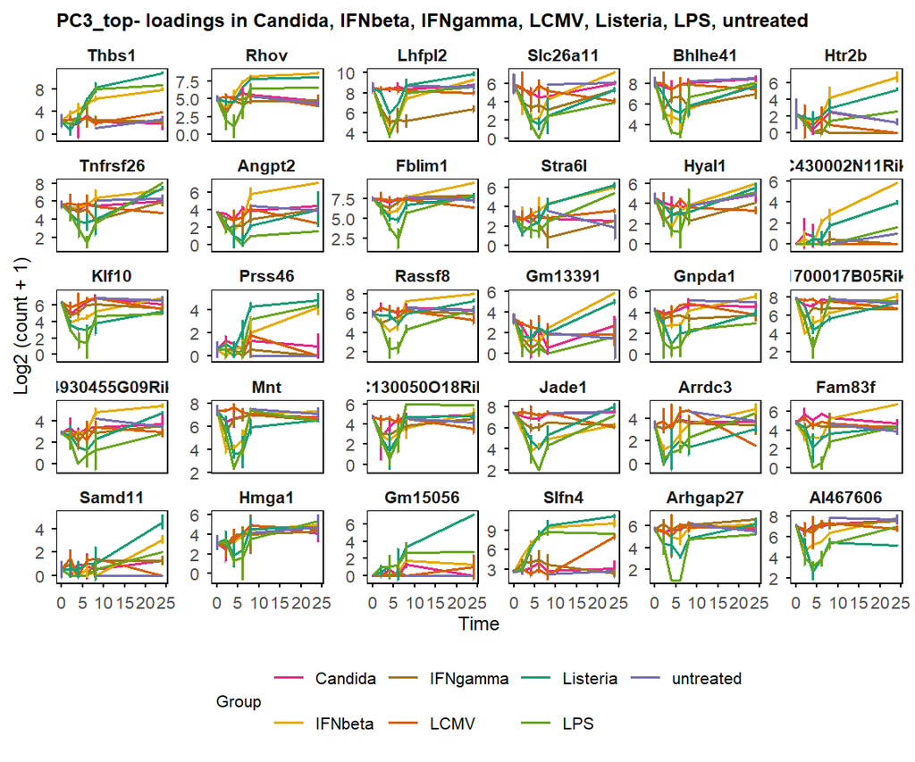

```r
pca_loadings_complete <- PC$loadings %>% as.data.frame()
loadings_list_complete <- list()
top_n <- 30

for (i in 1:3) {
    loadings_list_complete[[paste0("PC", i, "_top+")]] <- pca_loadings_complete %>%
        arrange(desc(get(paste0("PC", i)))) %>%
        head(top_n) %>%
        row.names()
    loadings_list_complete[[paste0("PC", i, "_top-")]] <- pca_loadings_complete %>%
        arrange(get(paste0("PC", i))) %>%
        head(top_n) %>%
        row.names()
}

for (i in names(loadings_list_complete)) {
    plot_trend(table_mean_sd_orig,
        features = loadings_list_complete[[i]],
        title = paste0(i, " loadings"),
        ylab = "Log2 (count + 1)"
    )
}
```

### 7.1.1 GO enrichment

```r
background_pca <- row.names(pca_loadings_complete)

go_list_pca <- enrichGO_list(
    gene_list = loadings_list_complete,
    OrgDb = org.Mm.eg.db,
    universe = background_pca,
    keyType = "SYMBOL",
    simplify = FALSE
)
```

[output not shown]

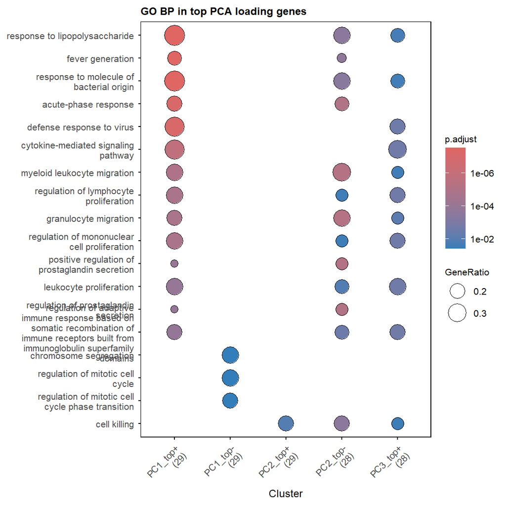

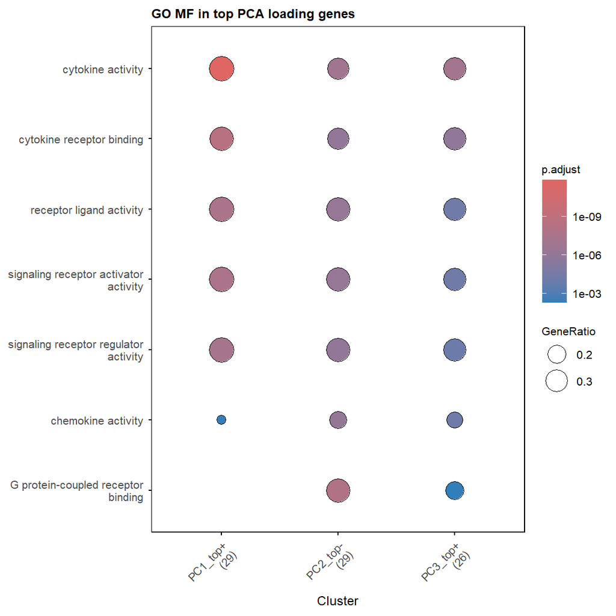

```
#> No significant GO CC terms found.
```

```r
plot_GO(go_list_pca$all,
    plot_dotplot = TRUE,
    showCategory_dotplot = 5,
    label = "top PCA loading genes"
)
```